# Risk Factor Analysis

## Outcome Variable

**Outcome Variable:** stunted

## Predictor Variables

**Intervention Variable:** tr

**Adjustment Set:**

unadjusted

## Stratifying Variables

The analysis was stratified on these variable(s):

- perdiar24
- agecat
- studyid
- country

## Data Summary

| perdiar24 | agecat | studyid | country | tr | stunted | n_cell | n |
| --- | --- | --- | --- | --- | --- | --- | --- |
| Q3 | 6 months | ki1000304-Vitamin-B12 | INDIA | Control | 0 | 3 | 22 |
| Q3 | 6 months | ki1000304-Vitamin-B12 | INDIA | Control | 1 | 1 | 22 |
| Q3 | 6 months | ki1000304-Vitamin-B12 | INDIA | Other | 0 | 12 | 22 |
| Q3 | 6 months | ki1000304-Vitamin-B12 | INDIA | Other | 1 | 6 | 22 |
| Q1 | 24 months | ki1000304-Vitamin-B12 | INDIA | Control | 0 | 8 | 43 |
| Q1 | 24 months | ki1000304-Vitamin-B12 | INDIA | Control | 1 | 7 | 43 |
| Q1 | 24 months | ki1000304-Vitamin-B12 | INDIA | Other | 0 | 14 | 43 |
| Q1 | 24 months | ki1000304-Vitamin-B12 | INDIA | Other | 1 | 14 | 43 |
| Q2 | 6 months | ki1000304-Vitamin-B12 | INDIA | Control | 0 | 1 | 10 |
| Q2 | 6 months | ki1000304-Vitamin-B12 | INDIA | Control | 1 | 1 | 10 |
| Q2 | 6 months | ki1000304-Vitamin-B12 | INDIA | Other | 0 | 5 | 10 |
| Q2 | 6 months | ki1000304-Vitamin-B12 | INDIA | Other | 1 | 3 | 10 |
| Q4 | 6 months | ki1000304-Vitamin-B12 | INDIA | Control | 0 | 5 | 38 |
| Q4 | 6 months | ki1000304-Vitamin-B12 | INDIA | Control | 1 | 4 | 38 |
| Q4 | 6 months | ki1000304-Vitamin-B12 | INDIA | Other | 0 | 23 | 38 |
| Q4 | 6 months | ki1000304-Vitamin-B12 | INDIA | Other | 1 | 6 | 38 |
| Q3 | 24 months | ki1000304-Vitamin-B12 | INDIA | Control | 0 | 3 | 21 |
| Q3 | 24 months | ki1000304-Vitamin-B12 | INDIA | Control | 1 | 1 | 21 |
| Q3 | 24 months | ki1000304-Vitamin-B12 | INDIA | Other | 0 | 8 | 21 |
| Q3 | 24 months | ki1000304-Vitamin-B12 | INDIA | Other | 1 | 9 | 21 |
| Q1 | 6 months | ki1000304-Vitamin-B12 | INDIA | Control | 0 | 2 | 11 |
| Q1 | 6 months | ki1000304-Vitamin-B12 | INDIA | Control | 1 | 0 | 11 |
| Q1 | 6 months | ki1000304-Vitamin-B12 | INDIA | Other | 0 | 7 | 11 |
| Q1 | 6 months | ki1000304-Vitamin-B12 | INDIA | Other | 1 | 2 | 11 |
| Q2 | 24 months | ki1000304-Vitamin-B12 | INDIA | Control | 0 | 5 | 20 |
| Q2 | 24 months | ki1000304-Vitamin-B12 | INDIA | Control | 1 | 4 | 20 |
| Q2 | 24 months | ki1000304-Vitamin-B12 | INDIA | Other | 0 | 7 | 20 |
| Q2 | 24 months | ki1000304-Vitamin-B12 | INDIA | Other | 1 | 4 | 20 |
| Q4 | 24 months | ki1000304-Vitamin-B12 | INDIA | Control | 0 | 3 | 23 |
| Q4 | 24 months | ki1000304-Vitamin-B12 | INDIA | Control | 1 | 1 | 23 |

[output cut: 117 more lines]

The following strata were considered:

- perdiar24: Q1, agecat: 24 months, studyid: ki1000304-Vitamin-B12, country: INDIA
- perdiar24: Q1, agecat: 24 months, studyid: kiGH5241-JiVitA-4, country: BANGLADESH
- perdiar24: Q1, agecat: 6 months, studyid: ki1000304-Vitamin-B12, country: INDIA
- perdiar24: Q1, agecat: 6 months, studyid: ki1000304b-SAS-FoodSuppl, country: INDIA
- perdiar24: Q1, agecat: 6 months, studyid: ki1017093b-PROVIDE, country: BANGLADESH
- perdiar24: Q1, agecat: 6 months, studyid: ki1112895-Guatemala BSC, country: GUATEMALA
- perdiar24: Q1, agecat: 6 months, studyid: kiGH5241-JiVitA-4, country: BANGLADESH
- perdiar24: Q1, agecat: Birth, studyid: kiGH5241-JiVitA-4, country: BANGLADESH
- perdiar24: Q2, agecat: 24 months, studyid: ki1000304-Vitamin-B12, country: INDIA
- perdiar24: Q2, agecat: 24 months, studyid: ki1017093b-PROVIDE, country: BANGLADESH
- perdiar24: Q2, agecat: 24 months, studyid: kiGH5241-JiVitA-4, country: BANGLADESH
- perdiar24: Q2, agecat: 6 months, studyid: ki1000304-Vitamin-B12, country: INDIA
- perdiar24: Q2, agecat: 6 months, studyid: ki1000304b-SAS-FoodSuppl, country: INDIA
- perdiar24: Q2, agecat: 6 months, studyid: ki1017093b-PROVIDE, country: BANGLADESH
- perdiar24: Q2, agecat: 6 months, studyid: ki1112895-Guatemala BSC, country: GUATEMALA
- perdiar24: Q2, agecat: 6 months, studyid: kiGH5241-JiVitA-4, country: BANGLADESH
- perdiar24: Q2, agecat: Birth, studyid: kiGH5241-JiVitA-4, country: BANGLADESH
- perdiar24: Q3, agecat: 24 months, studyid: ki1000304-Vitamin-B12, country: INDIA
- perdiar24: Q3, agecat: 24 months, studyid: kiGH5241-JiVitA-4, country: BANGLADESH
- perdiar24: Q3, agecat: 6 months, studyid: ki1000304-Vitamin-B12, country: INDIA
- perdiar24: Q3, agecat: 6 months, studyid: ki1000304b-SAS-FoodSuppl, country: INDIA
- perdiar24: Q3, agecat: 6 months, studyid: ki1017093b-PROVIDE, country: BANGLADESH
- perdiar24: Q3, agecat: 6 months, studyid: ki1112895-Guatemala BSC, country: GUATEMALA
- perdiar24: Q3, agecat: 6 months, studyid: kiGH5241-JiVitA-4, country: BANGLADESH
- perdiar24: Q3, agecat: Birth, studyid: kiGH5241-JiVitA-4, country: BANGLADESH
- perdiar24: Q4, agecat: 24 months, studyid: ki1000304-Vitamin-B12, country: INDIA
- perdiar24: Q4, agecat: 24 months, studyid: kiGH5241-JiVitA-4, country: BANGLADESH
- perdiar24: Q4, agecat: 6 months, studyid: ki1000304-Vitamin-B12, country: INDIA
- perdiar24: Q4, agecat: 6 months, studyid: ki1000304b-SAS-FoodSuppl, country: INDIA
- perdiar24: Q4, agecat: 6 months, studyid: ki1017093b-PROVIDE, country: BANGLADESH
- perdiar24: Q4, agecat: 6 months, studyid: ki1112895-Guatemala BSC, country: GUATEMALA
- perdiar24: Q4, agecat: 6 months, studyid: kiGH5241-JiVitA-4, country: BANGLADESH
- perdiar24: Q4, agecat: Birth, studyid: kiGH5241-JiVitA-4, country: BANGLADESH

### Dropped Strata

Some strata were dropped due to rare outcomes:

- perdiar24: Q3, agecat: 6 months, studyid: ki1000304-Vitamin-B12, country: INDIA
- perdiar24: Q2, agecat: 6 months, studyid: ki1000304-Vitamin-B12, country: INDIA
- perdiar24: Q4, agecat: 6 months, studyid: ki1000304-Vitamin-B12, country: INDIA
- perdiar24: Q3, agecat: 24 months, studyid: ki1000304-Vitamin-B12, country: INDIA
- perdiar24: Q1, agecat: 6 months, studyid: ki1000304-Vitamin-B12, country: INDIA
- perdiar24: Q2, agecat: 24 months, studyid: ki1000304-Vitamin-B12, country: INDIA
- perdiar24: Q4, agecat: 24 months, studyid: ki1000304-Vitamin-B12, country: INDIA
- perdiar24: Q1, agecat: 6 months, studyid: ki1000304b-SAS-FoodSuppl, country: INDIA
- perdiar24: Q2, agecat: 6 months, studyid: ki1000304b-SAS-FoodSuppl, country: INDIA
- perdiar24: Q2, agecat: 6 months, studyid: ki1017093b-PROVIDE, country: BANGLADESH
- perdiar24: Q3, agecat: 6 months, studyid: ki1017093b-PROVIDE, country: BANGLADESH
- perdiar24: Q4, agecat: 6 months, studyid: ki1017093b-PROVIDE, country: BANGLADESH
- perdiar24: Q1, agecat: 6 months, studyid: ki1017093b-PROVIDE, country: BANGLADESH
- perdiar24: Q2, agecat: 24 months, studyid: ki1017093b-PROVIDE, country: BANGLADESH
- perdiar24: Q1, agecat: 6 months, studyid: ki1112895-Guatemala BSC, country: GUATEMALA
- perdiar24: Q2, agecat: 6 months, studyid: ki1112895-Guatemala BSC, country: GUATEMALA
- perdiar24: Q3, agecat: 6 months, studyid: ki1112895-Guatemala BSC, country: GUATEMALA

## Methods Detail

We’re interested in the causal parameters $E[Y_a]$ for all values of $a \in \mathcal{A}$. These parameters represent the mean outcome if, possibly contrary to fact, we intervened to set all units to have $A=a$. Under the randomization and positivity assumptions, these are identified by the statistical parameters $\psi_a=E_W[E_{Y|A,W}(Y|A=a,W)]$. In addition, we’re interested in the mean of $Y$, $E[Y]$ under no intervention (the observed mean). We will estimate these parameters by using SuperLearner to fit the relevant likelihood factors – $E_{Y|A,W}(Y|A=a,W)$ and $p(A=a|W)$, and then updating our likelihood fit using a joint TMLE.

For unadjusted analyses ($W=\{\}$), initial likelihoods were estimated using Lrnr_glm to estimate the simple $E(Y|A)$ and Lrnr_mean to estimate $p(A)$. For adjusted analyses, a small library containing Lrnr_glmnet, Lrnr_xgboost, and Lrnr_mean was used.

Having estimated these parameters, we will then use the delta method to estimate relative risks and attributable risks relative to a prespecified baseline level of $A$.

```
##          stunted
## tr         0  1
##   Control  0  0
##   LNS      0  0
##   Other   20 12
```

# Results Detail

## Results Plots

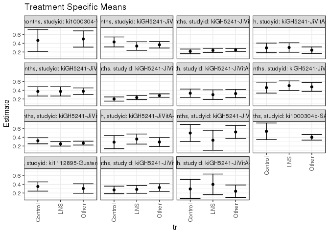

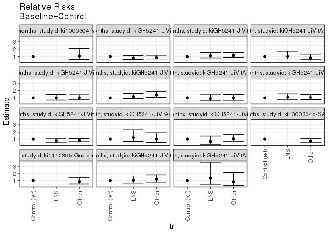

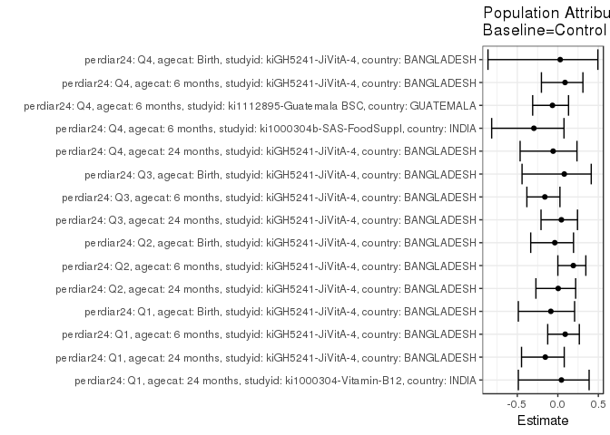

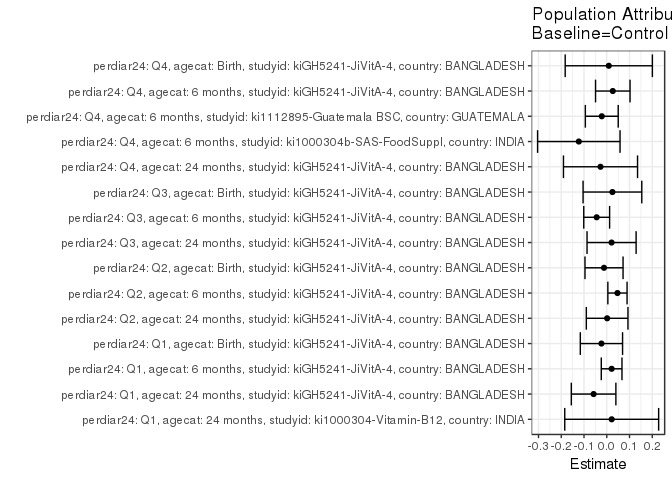

## Results Table

### Parameter: TSM

| perdiar24 | agecat | studyid | country | intervention_level | baseline_level | estimate | ci_lower | ci_upper |
| --- | --- | --- | --- | --- | --- | --- | --- | --- |
| Q1 | Birth | kiGH5241-JiVitA-4 | BANGLADESH | Control | NA | 0.2948718 | 0.1842474 | 0.4054962 |
| Q1 | Birth | kiGH5241-JiVitA-4 | BANGLADESH | LNS | NA | 0.3026316 | 0.1933969 | 0.4118663 |
| Q1 | Birth | kiGH5241-JiVitA-4 | BANGLADESH | Other | NA | 0.2408759 | 0.1653259 | 0.3164259 |
| Q1 | 6 months | kiGH5241-JiVitA-4 | BANGLADESH | Control | NA | 0.2144522 | 0.1611412 | 0.2677633 |
| Q1 | 6 months | kiGH5241-JiVitA-4 | BANGLADESH | LNS | NA | 0.2367347 | 0.1882494 | 0.2852200 |
| Q1 | 6 months | kiGH5241-JiVitA-4 | BANGLADESH | Other | NA | 0.2466258 | 0.2118448 | 0.2814068 |
| Q1 | 24 months | ki1000304-Vitamin-B12 | INDIA | Control | NA | 0.4666667 | 0.2112114 | 0.7221219 |
| Q1 | 24 months | ki1000304-Vitamin-B12 | INDIA | Other | NA | 0.5000000 | 0.3126090 | 0.6873910 |
| Q1 | 24 months | kiGH5241-JiVitA-4 | BANGLADESH | Control | NA | 0.4315789 | 0.3165486 | 0.5466093 |
| Q1 | 24 months | kiGH5241-JiVitA-4 | BANGLADESH | LNS | NA | 0.3364486 | 0.2377645 | 0.4351327 |
| Q1 | 24 months | kiGH5241-JiVitA-4 | BANGLADESH | Other | NA | 0.3655914 | 0.2913835 | 0.4397993 |
| Q2 | Birth | kiGH5241-JiVitA-4 | BANGLADESH | Control | NA | 0.3333333 | 0.2373206 | 0.4293461 |
| Q2 | Birth | kiGH5241-JiVitA-4 | BANGLADESH | LNS | NA | 0.3000000 | 0.1885412 | 0.4114588 |
| Q2 | Birth | kiGH5241-JiVitA-4 | BANGLADESH | Other | NA | 0.3252033 | 0.2316838 | 0.4187227 |
| Q2 | 6 months | kiGH5241-JiVitA-4 | BANGLADESH | Control | NA | 0.1990408 | 0.1510211 | 0.2470605 |
| Q2 | 6 months | kiGH5241-JiVitA-4 | BANGLADESH | LNS | NA | 0.2337963 | 0.1852208 | 0.2823718 |
| Q2 | 6 months | kiGH5241-JiVitA-4 | BANGLADESH | Other | NA | 0.2795699 | 0.2401177 | 0.3190221 |
| Q2 | 24 months | kiGH5241-JiVitA-4 | BANGLADESH | Control | NA | 0.3750000 | 0.2682035 | 0.4817965 |
| Q2 | 24 months | kiGH5241-JiVitA-4 | BANGLADESH | LNS | NA | 0.3750000 | 0.2683142 | 0.4816858 |
| Q2 | 24 months | kiGH5241-JiVitA-4 | BANGLADESH | Other | NA | 0.3785311 | 0.3014782 | 0.4555839 |
| Q3 | Birth | kiGH5241-JiVitA-4 | BANGLADESH | Control | NA | 0.2888889 | 0.1377588 | 0.4400189 |
| Q3 | Birth | kiGH5241-JiVitA-4 | BANGLADESH | LNS | NA | 0.3606557 | 0.2441290 | 0.4771825 |
| Q3 | Birth | kiGH5241-JiVitA-4 | BANGLADESH | Other | NA | 0.2926829 | 0.1899506 | 0.3954152 |
| Q3 | 6 months | kiGH5241-JiVitA-4 | BANGLADESH | Control | NA | 0.3206897 | 0.2509711 | 0.3904082 |
| Q3 | 6 months | kiGH5241-JiVitA-4 | BANGLADESH | LNS | NA | 0.2491468 | 0.1982570 | 0.3000365 |
| Q3 | 6 months | kiGH5241-JiVitA-4 | BANGLADESH | Other | NA | 0.2667984 | 0.2222847 | 0.3113122 |
| Q3 | 24 months | kiGH5241-JiVitA-4 | BANGLADESH | Control | NA | 0.4626866 | 0.3359964 | 0.5893767 |
| Q3 | 24 months | kiGH5241-JiVitA-4 | BANGLADESH | LNS | NA | 0.5063291 | 0.3951065 | 0.6175517 |
| Q3 | 24 months | kiGH5241-JiVitA-4 | BANGLADESH | Other | NA | 0.4803922 | 0.3763218 | 0.5844626 |
| Q4 | Birth | kiGH5241-JiVitA-4 | BANGLADESH | Control | NA | 0.2941176 | 0.0725884 | 0.5156469 |
| Q4 | Birth | kiGH5241-JiVitA-4 | BANGLADESH | LNS | NA | 0.4000000 | 0.1619029 | 0.6380971 |
| Q4 | Birth | kiGH5241-JiVitA-4 | BANGLADESH | Other | NA | 0.2413793 | 0.0977777 | 0.3849809 |
| Q4 | 6 months | ki1000304b-SAS-FoodSuppl | INDIA | Control | NA | 0.5384615 | 0.3464452 | 0.7304779 |
| Q4 | 6 months | ki1000304b-SAS-FoodSuppl | INDIA | Other | NA | 0.4009217 | 0.3355807 | 0.4662626 |
| Q4 | 6 months | ki1112895-Guatemala BSC | GUATEMALA | Control | NA | 0.3506494 | 0.2437017 | 0.4575970 |
| Q4 | 6 months | ki1112895-Guatemala BSC | GUATEMALA | Other | NA | 0.3043478 | 0.1954054 | 0.4132903 |
| Q4 | 6 months | kiGH5241-JiVitA-4 | BANGLADESH | Control | NA | 0.2719298 | 0.1848002 | 0.3590594 |
| Q4 | 6 months | kiGH5241-JiVitA-4 | BANGLADESH | LNS | NA | 0.2844037 | 0.1938225 | 0.3749848 |
| Q4 | 6 months | kiGH5241-JiVitA-4 | BANGLADESH | Other | NA | 0.3270440 | 0.2394362 | 0.4146519 |
| Q4 | 24 months | kiGH5241-JiVitA-4 | BANGLADESH | Control | NA | 0.5000000 | 0.3037324 | 0.6962676 |
| Q4 | 24 months | kiGH5241-JiVitA-4 | BANGLADESH | LNS | NA | 0.3333333 | 0.1025444 | 0.5641223 |
| Q4 | 24 months | kiGH5241-JiVitA-4 | BANGLADESH | Other | NA | 0.5238095 | 0.3724639 | 0.6751552 |

### Parameter: E(Y)

| perdiar24 | agecat | studyid | country | intervention_level | baseline_level | estimate | ci_lower | ci_upper |
| --- | --- | --- | --- | --- | --- | --- | --- | --- |
| Q1 | Birth | kiGH5241-JiVitA-4 | BANGLADESH | NA | NA | 0.2714777 | 0.2168416 | 0.3261137 |
| Q1 | 6 months | kiGH5241-JiVitA-4 | BANGLADESH | NA | NA | 0.2358708 | 0.2107720 | 0.2609696 |
| Q1 | 24 months | ki1000304-Vitamin-B12 | INDIA | NA | NA | 0.4883721 | 0.3371985 | 0.6395457 |
| Q1 | 24 months | kiGH5241-JiVitA-4 | BANGLADESH | NA | NA | 0.3737113 | 0.3206788 | 0.4267439 |
| Q2 | Birth | kiGH5241-JiVitA-4 | BANGLADESH | NA | NA | 0.3212996 | 0.2632280 | 0.3793712 |
| Q2 | 6 months | kiGH5241-JiVitA-4 | BANGLADESH | NA | NA | 0.2460766 | 0.2200979 | 0.2720553 |
| Q2 | 24 months | kiGH5241-JiVitA-4 | BANGLADESH | NA | NA | 0.3766938 | 0.3227477 | 0.4306399 |
| Q3 | Birth | kiGH5241-JiVitA-4 | BANGLADESH | NA | NA | 0.3138298 | 0.2448860 | 0.3827736 |
| Q3 | 6 months | kiGH5241-JiVitA-4 | BANGLADESH | NA | NA | 0.2764004 | 0.2451462 | 0.3076546 |
| Q3 | 24 months | kiGH5241-JiVitA-4 | BANGLADESH | NA | NA | 0.4838710 | 0.4186244 | 0.5491175 |
| Q4 | Birth | kiGH5241-JiVitA-4 | BANGLADESH | NA | NA | 0.3030303 | 0.1893679 | 0.4166927 |
| Q4 | 6 months | ki1000304b-SAS-FoodSuppl | INDIA | NA | NA | 0.4156379 | 0.3535454 | 0.4777303 |
| Q4 | 6 months | ki1112895-Guatemala BSC | GUATEMALA | NA | NA | 0.3287671 | 0.2523053 | 0.4052290 |
| Q4 | 6 months | kiGH5241-JiVitA-4 | BANGLADESH | NA | NA | 0.2984293 | 0.2466490 | 0.3502096 |
| Q4 | 24 months | kiGH5241-JiVitA-4 | BANGLADESH | NA | NA | 0.4725275 | 0.3644214 | 0.5806336 |

### Parameter: RR

| perdiar24 | agecat | studyid | country | intervention_level | baseline_level | estimate | ci_lower | ci_upper |
| --- | --- | --- | --- | --- | --- | --- | --- | --- |
| Q1 | Birth | kiGH5241-JiVitA-4 | BANGLADESH | Control | Control | 1.0000000 | 1.0000000 | 1.000000 |
| Q1 | Birth | kiGH5241-JiVitA-4 | BANGLADESH | LNS | Control | 1.0263158 | 0.6098644 | 1.727145 |
| Q1 | Birth | kiGH5241-JiVitA-4 | BANGLADESH | Other | Control | 0.8168835 | 0.5010287 | 1.331857 |
| Q1 | 6 months | kiGH5241-JiVitA-4 | BANGLADESH | Control | Control | 1.0000000 | 1.0000000 | 1.000000 |
| Q1 | 6 months | kiGH5241-JiVitA-4 | BANGLADESH | LNS | Control | 1.1039042 | 0.7999102 | 1.523427 |
| Q1 | 6 months | kiGH5241-JiVitA-4 | BANGLADESH | Other | Control | 1.1500267 | 0.8641390 | 1.530496 |
| Q1 | 24 months | ki1000304-Vitamin-B12 | INDIA | Control | Control | 1.0000000 | 1.0000000 | 1.000000 |
| Q1 | 24 months | ki1000304-Vitamin-B12 | INDIA | Other | Control | 1.0714286 | 0.5518842 | 2.080073 |
| Q1 | 24 months | kiGH5241-JiVitA-4 | BANGLADESH | Control | Control | 1.0000000 | 1.0000000 | 1.000000 |
| Q1 | 24 months | kiGH5241-JiVitA-4 | BANGLADESH | LNS | Control | 0.7795760 | 0.5244674 | 1.158773 |
| Q1 | 24 months | kiGH5241-JiVitA-4 | BANGLADESH | Other | Control | 0.8471020 | 0.6059852 | 1.184157 |
| Q2 | Birth | kiGH5241-JiVitA-4 | BANGLADESH | Control | Control | 1.0000000 | 1.0000000 | 1.000000 |
| Q2 | Birth | kiGH5241-JiVitA-4 | BANGLADESH | LNS | Control | 0.9000000 | 0.5624374 | 1.440160 |
| Q2 | Birth | kiGH5241-JiVitA-4 | BANGLADESH | Other | Control | 0.9756098 | 0.6494130 | 1.465653 |
| Q2 | 6 months | kiGH5241-JiVitA-4 | BANGLADESH | Control | Control | 1.0000000 | 1.0000000 | 1.000000 |
| Q2 | 6 months | kiGH5241-JiVitA-4 | BANGLADESH | LNS | Control | 1.1746151 | 0.8542703 | 1.615087 |
| Q2 | 6 months | kiGH5241-JiVitA-4 | BANGLADESH | Other | Control | 1.4045861 | 1.0621462 | 1.857430 |
| Q2 | 24 months | kiGH5241-JiVitA-4 | BANGLADESH | Control | Control | 1.0000000 | 1.0000000 | 1.000000 |
| Q2 | 24 months | kiGH5241-JiVitA-4 | BANGLADESH | LNS | Control | 1.0000000 | 0.6686591 | 1.495530 |
| Q2 | 24 months | kiGH5241-JiVitA-4 | BANGLADESH | Other | Control | 1.0094162 | 0.7113905 | 1.432295 |
| Q3 | Birth | kiGH5241-JiVitA-4 | BANGLADESH | Control | Control | 1.0000000 | 1.0000000 | 1.000000 |
| Q3 | Birth | kiGH5241-JiVitA-4 | BANGLADESH | LNS | Control | 1.2484237 | 0.6749775 | 2.309057 |
| Q3 | Birth | kiGH5241-JiVitA-4 | BANGLADESH | Other | Control | 1.0131332 | 0.5396234 | 1.902139 |
| Q3 | 6 months | kiGH5241-JiVitA-4 | BANGLADESH | Control | Control | 1.0000000 | 1.0000000 | 1.000000 |
| Q3 | 6 months | kiGH5241-JiVitA-4 | BANGLADESH | LNS | Control | 0.7769092 | 0.5766777 | 1.046664 |
| Q3 | 6 months | kiGH5241-JiVitA-4 | BANGLADESH | Other | Control | 0.8319521 | 0.6325891 | 1.094145 |
| Q3 | 24 months | kiGH5241-JiVitA-4 | BANGLADESH | Control | Control | 1.0000000 | 1.0000000 | 1.000000 |
| Q3 | 24 months | kiGH5241-JiVitA-4 | BANGLADESH | LNS | Control | 1.0943242 | 0.7702202 | 1.554809 |
| Q3 | 24 months | kiGH5241-JiVitA-4 | BANGLADESH | Other | Control | 1.0382669 | 0.7321020 | 1.472470 |
| Q4 | Birth | kiGH5241-JiVitA-4 | BANGLADESH | Control | Control | 1.0000000 | 1.0000000 | 1.000000 |
| Q4 | Birth | kiGH5241-JiVitA-4 | BANGLADESH | LNS | Control | 1.3600000 | 0.5206883 | 3.552221 |
| Q4 | Birth | kiGH5241-JiVitA-4 | BANGLADESH | Other | Control | 0.8206897 | 0.3143317 | 2.142741 |
| Q4 | 6 months | ki1000304b-SAS-FoodSuppl | INDIA | Control | Control | 1.0000000 | 1.0000000 | 1.000000 |
| Q4 | 6 months | ki1000304b-SAS-FoodSuppl | INDIA | Other | Control | 0.7445688 | 0.5030683 | 1.102003 |
| Q4 | 6 months | ki1112895-Guatemala BSC | GUATEMALA | Control | Control | 1.0000000 | 1.0000000 | 1.000000 |
| Q4 | 6 months | ki1112895-Guatemala BSC | GUATEMALA | Other | Control | 0.8679549 | 0.5423266 | 1.389100 |
| Q4 | 6 months | kiGH5241-JiVitA-4 | BANGLADESH | Control | Control | 1.0000000 | 1.0000000 | 1.000000 |
| Q4 | 6 months | kiGH5241-JiVitA-4 | BANGLADESH | LNS | Control | 1.0458716 | 0.6657019 | 1.643149 |
| Q4 | 6 months | kiGH5241-JiVitA-4 | BANGLADESH | Other | Control | 1.2026780 | 0.7920955 | 1.826086 |
| Q4 | 24 months | kiGH5241-JiVitA-4 | BANGLADESH | Control | Control | 1.0000000 | 1.0000000 | 1.000000 |
| Q4 | 24 months | kiGH5241-JiVitA-4 | BANGLADESH | LNS | Control | 0.6666667 | 0.3007835 | 1.477622 |
| Q4 | 24 months | kiGH5241-JiVitA-4 | BANGLADESH | Other | Control | 1.0476190 | 0.6434652 | 1.705618 |

### Parameter: PAR

| perdiar24 | agecat | studyid | country | intervention_level | baseline_level | estimate | ci_lower | ci_upper |
| --- | --- | --- | --- | --- | --- | --- | --- | --- |
| Q1 | Birth | kiGH5241-JiVitA-4 | BANGLADESH | Control | NA | -0.0233941 | -0.1162571 | 0.0694689 |
| Q1 | 6 months | kiGH5241-JiVitA-4 | BANGLADESH | Control | NA | 0.0214186 | -0.0240443 | 0.0668815 |
| Q1 | 24 months | ki1000304-Vitamin-B12 | INDIA | Control | NA | 0.0217054 | -0.1846497 | 0.2280605 |
| Q1 | 24 months | kiGH5241-JiVitA-4 | BANGLADESH | Control | NA | -0.0578676 | -0.1558291 | 0.0400939 |
| Q2 | Birth | kiGH5241-JiVitA-4 | BANGLADESH | Control | NA | -0.0120337 | -0.0957014 | 0.0716340 |
| Q2 | 6 months | kiGH5241-JiVitA-4 | BANGLADESH | Control | NA | 0.0470358 | 0.0048091 | 0.0892626 |
| Q2 | 24 months | kiGH5241-JiVitA-4 | BANGLADESH | Control | NA | 0.0016938 | -0.0897995 | 0.0931870 |
| Q3 | Birth | kiGH5241-JiVitA-4 | BANGLADESH | Control | NA | 0.0249409 | -0.1040906 | 0.1539724 |
| Q3 | 6 months | kiGH5241-JiVitA-4 | BANGLADESH | Control | NA | -0.0442893 | -0.1011127 | 0.0125341 |
| Q3 | 24 months | kiGH5241-JiVitA-4 | BANGLADESH | Control | NA | 0.0211844 | -0.0866659 | 0.1290347 |
| Q4 | Birth | kiGH5241-JiVitA-4 | BANGLADESH | Control | NA | 0.0089127 | -0.1827132 | 0.2005385 |
| Q4 | 6 months | ki1000304b-SAS-FoodSuppl | INDIA | Control | NA | -0.1228237 | -0.3040302 | 0.0583829 |
| Q4 | 6 months | ki1112895-Guatemala BSC | GUATEMALA | Control | NA | -0.0218822 | -0.0941296 | 0.0503652 |
| Q4 | 6 months | kiGH5241-JiVitA-4 | BANGLADESH | Control | NA | 0.0264995 | -0.0492916 | 0.1022906 |
| Q4 | 24 months | kiGH5241-JiVitA-4 | BANGLADESH | Control | NA | -0.0274725 | -0.1902690 | 0.1353239 |

### Parameter: PAF

| perdiar24 | agecat | studyid | country | intervention_level | baseline_level | estimate | ci_lower | ci_upper |
| --- | --- | --- | --- | --- | --- | --- | --- | --- |
| Q1 | Birth | kiGH5241-JiVitA-4 | BANGLADESH | Control | NA | -0.0861733 | -0.4873586 | 0.2068002 |
| Q1 | 6 months | kiGH5241-JiVitA-4 | BANGLADESH | Control | NA | 0.0908065 | -0.1249505 | 0.2651829 |
| Q1 | 24 months | ki1000304-Vitamin-B12 | INDIA | Control | NA | 0.0444444 | -0.4872374 | 0.3860520 |
| Q1 | 24 months | kiGH5241-JiVitA-4 | BANGLADESH | Control | NA | -0.1548457 | -0.4480820 | 0.0790103 |
| Q2 | Birth | kiGH5241-JiVitA-4 | BANGLADESH | Control | NA | -0.0374532 | -0.3345982 | 0.1935332 |
| Q2 | 6 months | kiGH5241-JiVitA-4 | BANGLADESH | Control | NA | 0.1911430 | 0.0002446 | 0.3455903 |
| Q2 | 24 months | kiGH5241-JiVitA-4 | BANGLADESH | Control | NA | 0.0044964 | -0.2705940 | 0.2200282 |
| Q3 | Birth | kiGH5241-JiVitA-4 | BANGLADESH | Control | NA | 0.0794727 | -0.4416241 | 0.4122112 |
| Q3 | 6 months | kiGH5241-JiVitA-4 | BANGLADESH | Control | NA | -0.1602360 | -0.3821077 | 0.0260183 |
| Q3 | 24 months | kiGH5241-JiVitA-4 | BANGLADESH | Control | NA | 0.0437811 | -0.2074129 | 0.2427159 |
| Q4 | Birth | kiGH5241-JiVitA-4 | BANGLADESH | Control | NA | 0.0294118 | -0.8619548 | 0.4940578 |
| Q4 | 6 months | ki1000304b-SAS-FoodSuppl | INDIA | Control | NA | -0.2955065 | -0.8164413 | 0.0760301 |
| Q4 | 6 months | ki1112895-Guatemala BSC | GUATEMALA | Control | NA | -0.0665584 | -0.3106181 | 0.1320531 |
| Q4 | 6 months | kiGH5241-JiVitA-4 | BANGLADESH | Control | NA | 0.0887966 | -0.2025449 | 0.3095545 |
| Q4 | 24 months | kiGH5241-JiVitA-4 | BANGLADESH | Control | NA | -0.0581395 | -0.4655482 | 0.2360134 |